# Clustering Cycling performance data

AlexandeR Noll

# Goals

The goal of this mini-project is to cluster some cycling rides: the input data is a time series that contains my wattage at every point in time.

# Data

The data was recorded using the Wahoo Kickr Snap device attached to a road bike. The `.fit` files are available on [GitHub](https://github.com/NOllAl/ClusterCycling). This file format can be read with the `cycleRtools`https://cran.r-project.org/web/packages/cycleRtools/vignettes/cycling_data_analysis.html package. Let us look at one example ride:

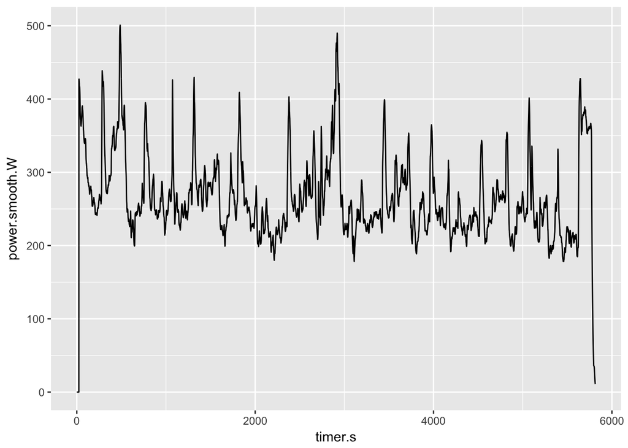

```r
last_ride <- read_ride("../data/2017-09-24-15-11-48.fit")

last_ride %>%
  ggplot(aes(timer.s, power.smooth.W)) +
  geom_line()
```

```r
parse_ride <- function(file) {
  file <- stringr::str_c("../data/", file)
  datetime <- stringr::str_sub(file, 9, 27)

  try({
    ride <- read_ride(file) %>%
      mutate(datetime = datetime) %>%
      select(datetime, timer.s, power.smooth.W)

    return(ride)
  })
  return(NULL)
}

load_rides <- function() {
  all_files <- list.files("../data")

  map_df(all_files, parse_ride)
}

all_rides <- load_rides()
```

We have 120 rides an totally 325349 observations.

The data are downsampled to minutewise to make the clustering faster.

```r
all_rides_nested <- all_rides %>%
  group_by(datetime, minute = floor(timer.s / 60)) %>%
  summarise(power.smooth.W = mean(power.smooth.W)) %>%
  group_by(datetime) %>%
  nest()
```

Now, we use the `dtwclust` package to combine DTW with a clustering technique. This combination uses DTW to compute pairwise distances and then applies a clustering algorithm to the resulting distance matrix (obiously, the clustering algorithm needs to be able to work with a distance matrix only).

```r
library(dtwclust)
```

```r
set.seed(1)
clustering <- all_rides_nested$data %>% map(pull, power.smooth.W) %>%
  tsclust(k = 3, type = "partitional")
```

Let us make a plot:

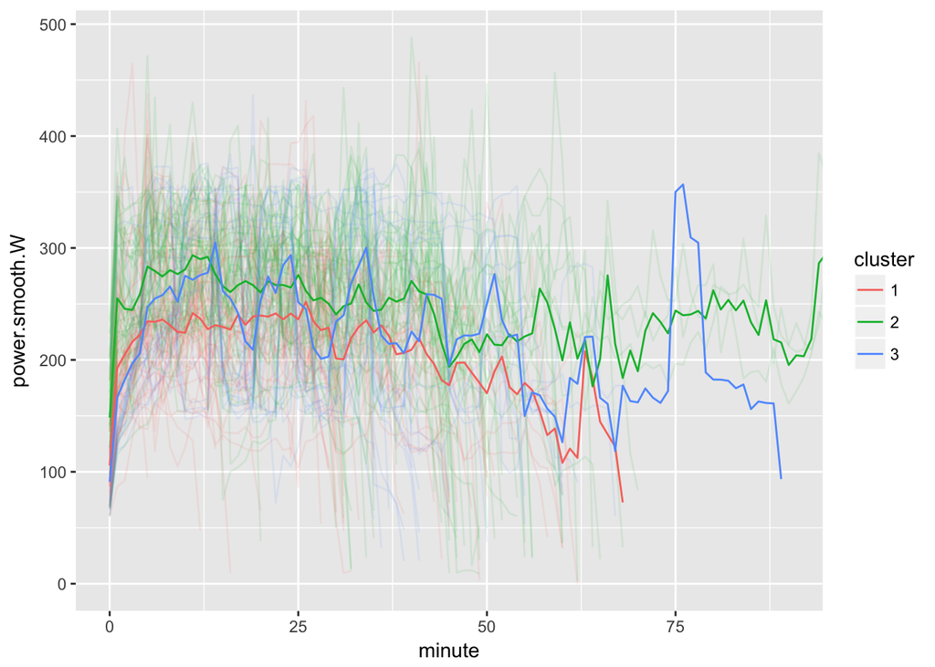

```r
all_rides_nested %>%
  mutate(cluster = factor(clustering@cluster)) %>%
  unnest() %>%
  ggplot(aes(minute, power.smooth.W, color = cluster)) +
  geom_line(aes(group = datetime), alpha = 0.10) +
  stat_summary(fun.y = "mean", aes(group = cluster, color = cluster), geom = "line") +
  coord_cartesian(xlim = c(0, 90))
```

There is much more that could be done (optimization, e.g.).